# House Pricing Prediction ‘AMES’ Dataset

Ricardo De León Flores.

Date: 13 de February de 2024

# Classification

## Desicion Tree

### Data setup

```r
# create a new ames working copy
ames_df <- data.frame(ames)
```

Visualize a box plot from the Sales_price column

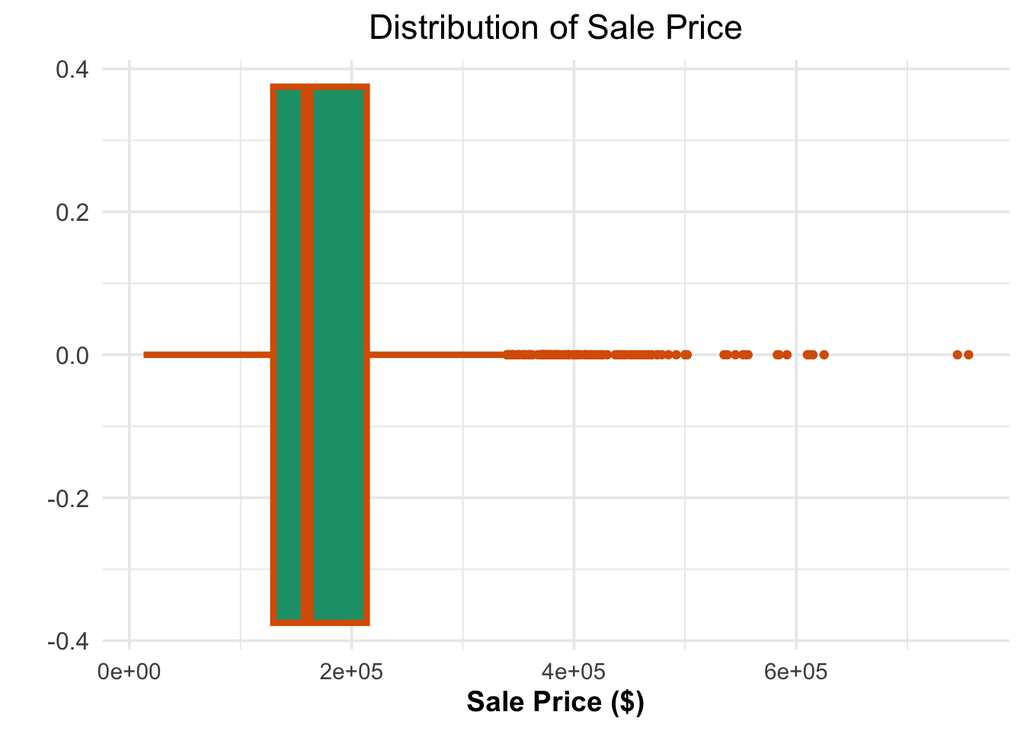

```r
my_colors <- c("#1b9e77", "#d95f02")

ggplot(ames, aes(y = Sale_Price)) +
  geom_boxplot(fill = my_colors[1], color = my_colors[2], size = 1.5) +
  labs(y = "Sale Price ($)", x = "") +
  coord_flip() +
  theme_minimal(base_size = 14) +
  theme(axis.text.y = element_text(size = 12),
        axis.title.x = element_text(size = 14, face = "bold"),
        axis.title.y = element_text(size = 14, face = "bold")) +
  ggtitle("Distribution of Sale Price") +
  theme(plot.title = element_text(hjust = 0.5))
```

```r
# Calculate the 75th quantile of Sale_Price
quantile_75 <- quantile(ames$Sale_Price, probs = 0.75)

# Subset the ames dataset to get only rows where Sale_Price is in the 75th quantile
data <- ames[ames$Sale_Price <= quantile_75, ]

# Rename the dataframe to "data"
data_df <- as.data.frame(data)

# Convert the outcome variable to a factor
data_df$Sale_Price <- factor(data_df$Sale_Price)

# View the first few rows of the dataframe
head(data_df)
```

```
##                           MS_SubClass                MS_Zoning Lot_Frontage
## 1 One_Story_1946_and_Newer_All_Styles Residential_High_Density           80
## 2 One_Story_1946_and_Newer_All_Styles  Residential_Low_Density           81
## 3            Two_Story_1946_and_Newer  Residential_Low_Density           74
## 4            Two_Story_1946_and_Newer  Residential_Low_Density           78
## 5        One_Story_PUD_1946_and_Newer  Residential_Low_Density           41
## 6        One_Story_PUD_1946_and_Newer  Residential_Low_Density           43
##   Lot_Area Street           Alley          Lot_Shape Land_Contour Utilities
## 1    11622   Pave No_Alley_Access            Regular          Lvl    AllPub
## 2    14267   Pave No_Alley_Access Slightly_Irregular          Lvl    AllPub
## 3    13830   Pave No_Alley_Access Slightly_Irregular          Lvl    AllPub
## 4     9978   Pave No_Alley_Access Slightly_Irregular          Lvl    AllPub
## 5     4920   Pave No_Alley_Access            Regular          Lvl    AllPub
## 6     5005   Pave No_Alley_Access Slightly_Irregular          HLS    AllPub
##   Lot_Config Land_Slope Neighborhood Condition_1 Condition_2 Bldg_Type
```

[output cut: 83 more lines]

Now we can visualize the 75 quantile data split from the rest of data

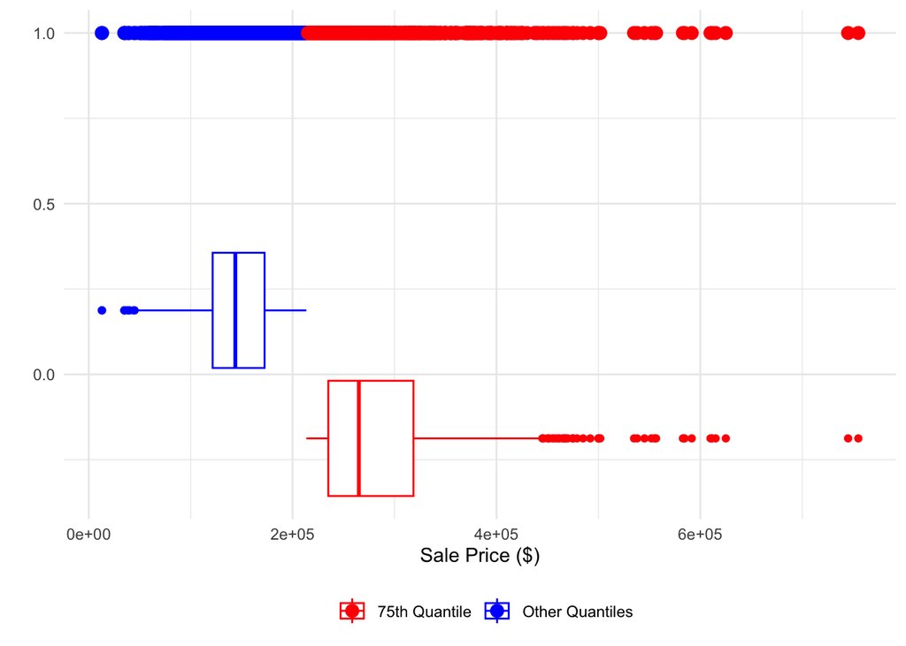

```r
ggplot(ames, aes(y = Sale_Price, color = ifelse(Sale_Price >= quantile_75, "75th Quantile", "Other Quantiles"))) +
  geom_boxplot() + # Boxplot for all data
  geom_point(aes(x = 1), size = 3) +  # Overlay points
  scale_color_manual(values = c("75th Quantile" = "red", "Other Quantiles" = "blue")) +  # Custom color for points
  labs(x = "", y = "Sale Price ($)", color = "") +  # Label axes and legend
  coord_flip() +  # Rotate the axes
  theme_minimal() +  # Apply minimal theme
  theme(legend.position = "bottom")  # Move legend to the bottom
```

### Split train and test

First step is to split into **train** and **test** the dataset, using a seed to work with the same results always.

```r
set.seed(123)
split_initial <- initial_split(data = data_df,
              prop = 0.8, # training proportion
              strata = Sale_Price, # Variable objetivo
              # hace el split lo más distribuido del precio automaticamente
              )

data_train <- training(split_initial)
data_test <- testing(split_initial)
```

### Recipe

Next step is to apply the **recipe** and create a transformation, should be applied to both, train and test datasets.

```r
transformer <- recipe(formula = Sale_Price ~.,
        data = data_train) |>
        step_naomit(all_predictors()) |>
        step_nzv(all_predictors()) |>
        step_center(all_numeric(), -all_outcomes()) |>
        step_scale(all_numeric(), -all_outcomes()) |>
        step_dummy(all_nominal(), -all_outcomes())

transformer_fit <- prep(transformer)

data_train_prep <- bake(transformer_fit, new_data = data_train)
data_test_prep <- bake(transformer_fit, new_data = data_test)
```

### H-parameters and C-Validation

Once we have the recipe, continue with the model, hyper-parameters and cross-validation

```r
#Define the hyper parameter to optimize

model_tree <- decision_tree(mode = "classification", #regression, classification
              tree_depth = tune(),
              min_n = tune()) %>%
      set_engine(engine = "rpart")

cv_folds <- vfold_cv(data = data_train,
         v = 5, #numero de particiones
         strata = Sale_Price #variable objetivo
         )
```

### Grid Search

Selected **Grid regular** as the grid option to select the hyper-parameters.

```r
tic("Classification Decision tree time")
#Grid search (Example)
hiperpar_grid <- grid_regular(
  #Rango de busqueda de cada hiperparametro
  tree_depth(range = c(1,10),trans = NULL),
  min_n( range = c(2,50),trans = NULL ),
  #numero de valores para cada hiperametro
  levels = c(10,10)
)

# Define classification metrics
classification_metrics <- metric_set(
  accuracy
)

# Optimization
grid_fit <- tune_grid(
  object = model_tree,
  preprocessor = transformer,
  resamples = cv_folds,
  metrics = classification_metrics,  # Use classification metrics
  control = control_grid(save_pred = TRUE),
  grid = hiperpar_grid
)
time_class_decision_tree_model <- toc()
```

```
## Classification Decision tree time: 262.027 sec elapsed
```

### Evaluation of training error

```r
# Show metrics
grid_fit %>%
  unnest(.metrics)
```

```
## # A tibble: 500 × 10
##    splits             id    tree_depth min_n .metric  .estimator .estimate
##    <list>             <chr>      <int> <int> <chr>    <chr>          <dbl>
##  1 <split [1407/352]> Fold1          1     2 accuracy multiclass   0.00852
##  2 <split [1407/352]> Fold1          2     2 accuracy multiclass   0.00852
##  3 <split [1407/352]> Fold1          3     2 accuracy multiclass   0.00852
##  4 <split [1407/352]> Fold1          4     2 accuracy multiclass   0.00852
##  5 <split [1407/352]> Fold1          5     2 accuracy multiclass   0.00852
##  6 <split [1407/352]> Fold1          6     2 accuracy multiclass   0.00852
##  7 <split [1407/352]> Fold1          7     2 accuracy multiclass   0.00852
##  8 <split [1407/352]> Fold1          8     2 accuracy multiclass   0.00852
##  9 <split [1407/352]> Fold1          9     2 accuracy multiclass   0.00852
## 10 <split [1407/352]> Fold1         10     2 accuracy multiclass   0.00852
## # ℹ 490 more rows
## # ℹ 3 more variables: .config <chr>, .notes <list>, .predictions <list>
```

```r
# Summarize metrics
grid_fit %>%
  collect_metrics(summarize = TRUE)
```

```
## # A tibble: 100 × 8
##    tree_depth min_n .metric  .estimator   mean     n std_err .config
##         <int> <int> <chr>    <chr>       <dbl> <int>   <dbl> <chr>
##  1          1     2 accuracy multiclass 0.0108     5 0.00209 Preprocessor1_Mode…
##  2          2     2 accuracy multiclass 0.0108     5 0.00209 Preprocessor1_Mode…
##  3          3     2 accuracy multiclass 0.0108     5 0.00209 Preprocessor1_Mode…
##  4          4     2 accuracy multiclass 0.0108     5 0.00209 Preprocessor1_Mode…
##  5          5     2 accuracy multiclass 0.0108     5 0.00209 Preprocessor1_Mode…
##  6          6     2 accuracy multiclass 0.0108     5 0.00209 Preprocessor1_Mode…
##  7          7     2 accuracy multiclass 0.0108     5 0.00209 Preprocessor1_Mode…
##  8          8     2 accuracy multiclass 0.0108     5 0.00209 Preprocessor1_Mode…
##  9          9     2 accuracy multiclass 0.0108     5 0.00209 Preprocessor1_Mode…
## 10         10     2 accuracy multiclass 0.0108     5 0.00209 Preprocessor1_Mode…
## # ℹ 90 more rows
```

```r
# Show best models based on RMSE
grid_fit %>%
  show_best(metric = "accuracy", n = 5)
```

```
## # A tibble: 5 × 8
##   tree_depth min_n .metric  .estimator   mean     n std_err .config
##        <int> <int> <chr>    <chr>       <dbl> <int>   <dbl> <chr>
## 1          1     2 accuracy multiclass 0.0108     5 0.00209 Preprocessor1_Model…
## 2          2     2 accuracy multiclass 0.0108     5 0.00209 Preprocessor1_Model…
## 3          3     2 accuracy multiclass 0.0108     5 0.00209 Preprocessor1_Model…
## 4          4     2 accuracy multiclass 0.0108     5 0.00209 Preprocessor1_Model…
## 5          5     2 accuracy multiclass 0.0108     5 0.00209 Preprocessor1_Model…
```

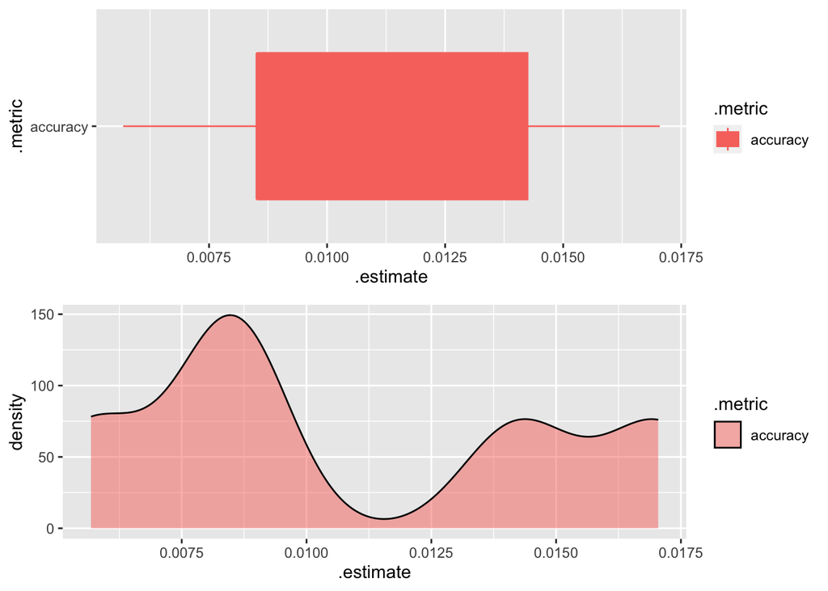

```r
# Create boxplot
p1 <- grid_fit %>%
  collect_metrics(summarize = FALSE) %>%
  ggplot(aes(x = .metric, y = .estimate, fill = .metric, color = .metric)) +
  geom_boxplot() +
  coord_flip()

# Create density plot
p2 <-  grid_fit %>%
  collect_metrics(summarize = FALSE) %>%
  ggplot(aes(x = .estimate, fill = .metric)) +
  geom_density(alpha = 0.5)

# Arrange plots
ggarrange(p1, p2, nrow = 2)
```

### Final Model

```r
# Select the best hyperparameters based on accuracy
best_hip <- select_best(grid_fit, metric = "accuracy")

# Finalize the model with the best hyperparameters
final_model_tree <- finalize_model(x = model_tree, parameters = best_hip)

# Fit the final model
final_model_tree_fit <- final_model_tree %>%
  fit(formula = Sale_Price ~ ., data = data_train_prep)
```

### Validation

```r
# Make predictions
predicciones <- final_model_tree_fit %>%
  predict(new_data = data_test_prep, type = "class")

# Create a confusion matrix
confusion <- confusionMatrix(predicciones$.pred_class, data_test_prep$Sale_Price)

confusion$overall
```

```
##       Accuracy          Kappa  AccuracyLower  AccuracyUpper   AccuracyNull
##    0.015909091    0.000000000    0.006419587    0.032502873    0.020454545
## AccuracyPValue  McnemarPValue
##    0.796039108            NaN
```